# 1. Data Sources & Collection

CMS Nursing Home Provider Information - https://data.cms.gov/provider-data/dataset/4pq5-n9py (2017 - 2021)

CMS Medicare Claims Quality Measures - https://data.cms.gov/provider-data/dataset/ijh5-nb2v (April 2020 - March 2021)

CMS Survey Summary - https://data.cms.gov/provider-data/dataset/tbry-pc2d (2017 - 2020)

CMS MDS Quality Measures - https://data.cms.gov/provider-data/dataset/djen-97ju (April 2020 - March 2021)

CMS COVID-19 Nursing Home Data - https://data.cms.gov/covid-19/covid-19-nursing-home-data (April 2020 - December 2020, January 2021 - March 2021)

# 2. Construct dataset

```python
import xgboost
import pandas as pd
import numpy as np
import os
import matplotlib.pyplot as plt
import seaborn as sns
import statsmodels.api as sm
import scipy.stats as stats
```

```python
# Set directory
os.chdir('C:/Users/erpin/Documents/CIND820')
```

```python
p = 'NH_ProviderInfo_Jan2022.csv'
s = 'NH_SurveySummary_Nov2021.csv'
m = 'NH_QualityMsr_MDS_Nov2021.csv'
c = 'NH_QualityMsr_Claims_Nov2021.csv'
cov = 'faclevel_2020.csv'

# Select columns from provider dataset
dfp = pd.read_csv(p, dtype={'Federal Provider Number':'str'}, encoding='cp1252')
colsp= [0,1,4,9,10,11,30,48,50,58,59,60,87,88,89]
dfp = dfp[dfp.columns[colsp]]
dfp['Federal Provider Number'] = dfp['Federal Provider Number'].apply(lambda x: x.lstrip('0'))

# Select columns from MDS dataset
dfm = pd.read_csv(m, dtype={'Federal Provider Number':'str'}, encoding='cp1252')
LS = dfm[dfm['Resident type']== 'Long Stay']
colsm = [0,7,8,17]
LS = LS[LS.columns[colsm]]
LSpivot = LS.pivot(index=['Federal Provider Number', 'Resident type'], columns='Measure Description', values='Four Quarter Average Score')
LSpivot.reset_index(drop=False, inplace=True)
LSpivot['Federal Provider Number'] = LSpivot['Federal Provider Number'].apply(lambda x: x.lstrip('0'))

# Select columns from surveys dataset
dfs = pd.read_csv(s, dtype={'Federal Provider Number':'str'}, encoding='cp1252')
colss = [0,6,7,9,10]
dfs = dfs[dfs.columns[colss]]
dfs = dfs[dfs['Inspection Cycle']==3]
dfs.to_csv('inspection.csv')
dfs['Federal Provider Number'] = dfs['Federal Provider Number'].apply(lambda x: x.lstrip('0'))

#select columns from COVID 2020 dataset
dfcov = pd.read_csv(cov, dtype={'Federal Provider Number':'str'})
colcov = [1,13,19,22]
dfcov = dfcov[dfcov.columns[colcov]]
dfcov['Total Number of Occupied Beds'] = dfcov['Total Number of Occupied Beds'].replace(0, np.nan)
dfcov['Confirmed COVID-19 Cases Per Occupied Beds'] = dfcov['Residents Weekly Confirmed COVID-19']/dfcov['Total Number of Occupied Beds']
dfcov['COVID-19 Deaths Per Occupied Beds'] = dfcov['Residents Weekly COVID-19 Deaths']/dfcov['Total Number of Occupied Beds']
dfcovm = dfcov.groupby(['Federal Provider Number']).mean().reset_index()
dfcovm['Federal Provider Number'] = dfcovm['Federal Provider Number'].apply(lambda x: x.lstrip('0'))

#Select columns from claims dataset
dfc = pd.read_csv(c, dtype={'Federal Provider Number':'str'}, encoding='cp1252')
dfc = dfc[dfc['Measure Description']=='Number of outpatient emergency department visits per 1000 long-stay resident days']
colc = [0,7,9]
dfc = dfc[dfc.columns[colc]]
dfc['Federal Provider Number'] = dfc['Federal Provider Number'].apply(lambda x: x.lstrip('0'))

df1 = pd.merge(dfp, LSpivot, on='Federal Provider Number', how='left')
df2 = pd.merge(df1, dfs, on='Federal Provider Number', how='left')
df3 = pd.merge(df2, dfcovm, on='Federal Provider Number', how='left')
final_df = pd.merge(df3, dfc, on='Federal Provider Number', how='left')
```

```python
from IPython.core.display import display, HTML
display(HTML("<style>.container { width:100% !important; }</style>"))
```

# 3. Data Cleaning

```python
#Checking columns
final_df.columns.tolist()
```

```
['Federal Provider Number',
 'Provider Name',
 'Provider State',
 'Ownership Type',
 'Number of Certified Beds',
 'Average Number of Residents per Day',
 'Long-Stay QM Rating',
 'Total nursing staff turnover',
 'Registered Nurse turnover',
 'Adjusted Nurse Aide Staffing Hours per Resident per Day',
 'Adjusted LPN Staffing Hours per Resident per Day',
 'Adjusted RN Staffing Hours per Resident per Day',
 'Number of Facility Reported Incidents',
 'Number of Substantiated Complaints',
 'Number of Citations from Infection Control Inspections',
 'Resident type',
 'Percentage of high risk long-stay residents with pressure ulcers',
 'Percentage of long-stay residents assessed and appropriately given the pneumococcal vaccine',
 'Percentage of long-stay residents assessed and appropriately given the seasonal influenza vaccine',
 'Percentage of long-stay residents experiencing one or more falls with major injury',
 'Percentage of long-stay residents who have depressive symptoms',
 'Percentage of long-stay residents who lose too much weight',
 'Percentage of long-stay residents who received an antianxiety or hypnotic medication',
 'Percentage of long-stay residents who received an antipsychotic medication',
 'Percentage of long-stay residents who were physically restrained',
 'Percentage of long-stay residents whose ability to move independently worsened',
 'Percentage of long-stay residents whose need for help with daily activities has increased',
 'Percentage of long-stay residents with a catheter inserted and left in their bladder',
 'Percentage of long-stay residents with a urinary tract infection',
 'Percentage of low risk long-stay residents who lose control of their bowels or bladder',
 'Inspection Cycle',
 'Health Survey Date',
 'Total Number of Health Deficiencies',
 'Total Number of Fire Safety Deficiencies',
 'Residents Weekly Confirmed COVID-19',
 'Residents Weekly COVID-19 Deaths',
 'Total Number of Occupied Beds',
 'Confirmed COVID-19 Cases Per Occupied Beds',
 'COVID-19 Deaths Per Occupied Beds',
 'Measure Description',
 'Adjusted Score']
```

```python
# Rename 'Adjusted Score' to 'Number of outpatient emergency department visits per 1000 long-stay resident days'
final_df.rename(columns={'Adjusted Score': 'Number of outpatient emergency department visits per 1000 long-stay resident days'}, inplace=True)
```

```python
#Remove unnecessary columns - Resident type, Inspection Cycle, Measure Description, Residents Weekly Confirmed COVID-19, Residents Weekly COVID-19 Deaths, Total Number of Occupied Beds
final_df.drop(['Resident type', 'Inspection Cycle', 'Measure Description', 'Residents Weekly Confirmed COVID-19', 'Residents Weekly COVID-19 Deaths', 'Total Number of Occupied Beds', 'Health Survey Date', 'Provider State'], axis=1, inplace=True)
```

```python
# Count number of rows - 15238
len(final_df.index)
```

```
15238
```

```python
#Check for duplicate rows - No duplicates
final_df[final_df['Federal Provider Number'].duplicated() == True].sort_values('Federal Provider Number')
```

|  | Federal Provider Number | Provider Name | Ownership Type | Number of Certified Beds | Average Number of Residents per Day | Long-Stay QM Rating | Total nursing staff turnover | Registered Nurse turnover | Adjusted Nurse Aide Staffing Hours per Resident per Day | Adjusted LPN Staffing Hours per Resident per Day | ... | Percentage of long-stay residents whose ability to move independently worsened | Percentage of long-stay residents whose need for help with daily activities has increased | Percentage of long-stay residents with a catheter inserted and left in their bladder | Percentage of long-stay residents with a urinary tract infection | Percentage of low risk long-stay residents who lose control of their bowels or bladder | Total Number of Health Deficiencies | Total Number of Fire Safety Deficiencies | Confirmed COVID-19 Cases Per Occupied Beds | COVID-19 Deaths Per Occupied Beds | Number of outpatient emergency department visits per 1000 long-stay resident days |
| --- | --- | --- | --- | --- | --- | --- | --- | --- | --- | --- | --- | --- | --- | --- | --- | --- | --- | --- | --- | --- | --- |

0 rows × 33 columns

```python
#Check for null values in dependent value - 2241 rows
final_df['Number of outpatient emergency department visits per 1000 long-stay resident days'].isna().sum()
#Remove 2241 rows with null dependent value
mod_df = final_df.dropna(how='any', subset=['Number of outpatient emergency department visits per 1000 long-stay resident days'])
```

```python
#Nulls per column
colnulls = mod_df.isnull().sum(axis=0).to_frame(name='Column Nulls')
```

```python
# Count nulls per row
rownulls = mod_df.set_index('Provider Name').isnull().sum(axis=1)
rownulls.count()
rownulls[rownulls > 15].count()
rownulls.sort_values(ascending=False)
```

```
Provider Name
HEDDINGTON OAKS                                      20
GOLDEN CROSS HEALTH CARE                             20
GREENE COUNTY NURSING HOME                           20
THE VILLAGES OF GENERAL BAPTIST HEALTH CARE  EAST    20
ROLLING MEADOWS                                      17
                                                     ..
HARROGATE                                             0
LAKELAND HEALTH CARE CENTER                           0
ASPEN HILLS HEALTHCARE CENTER                         0
PROMEDICA SKILLED NURSING & REHAB - MOUNTAINSIDE      0
LIFE CARE CENTER OF SULLIVAN                          0
Length: 12997, dtype: int64
```

```python
# Coding the 'Ownership' Categorical Variable for Random Forest Regression
mod_df['Ownership Type'].value_counts()
categorizing_ownership = {'Ownership Type': {
    'For profit - Corporation': 1,
    'Non profit - Corporation': 0,
    'For profit - Limited Liability company': 1,
    'For profit - Individual': 1,
    'For profit - Partnership': 1,
    'Government - County': 2,
    'Non profit - Church related': 0,
    'Non profit - Other': 0,
    'Government - Hospital district': 2,
    'Government - State': 2,
    'Government - City': 2,
    'Government - City/county': 2,
    'Government - Federal': 2}}
mod_df = mod_df.replace(categorizing_ownership)
mod_df.head()
```

|  | Federal Provider Number | Provider Name | Ownership Type | Number of Certified Beds | Average Number of Residents per Day | Long-Stay QM Rating | Total nursing staff turnover | Registered Nurse turnover | Adjusted Nurse Aide Staffing Hours per Resident per Day | Adjusted LPN Staffing Hours per Resident per Day | ... | Percentage of long-stay residents whose ability to move independently worsened | Percentage of long-stay residents whose need for help with daily activities has increased | Percentage of long-stay residents with a catheter inserted and left in their bladder | Percentage of long-stay residents with a urinary tract infection | Percentage of low risk long-stay residents who lose control of their bowels or bladder | Total Number of Health Deficiencies | Total Number of Fire Safety Deficiencies | Confirmed COVID-19 Cases Per Occupied Beds | COVID-19 Deaths Per Occupied Beds | Number of outpatient emergency department visits per 1000 long-stay resident days |
| --- | --- | --- | --- | --- | --- | --- | --- | --- | --- | --- | --- | --- | --- | --- | --- | --- | --- | --- | --- | --- | --- |
| 0 | 15009 | BURNS NURSING HOME, INC. | 1 | 57 | 53.2 | 5.0 | NaN | NaN | NaN | NaN | ... | 28.180706 | 15.060243 | 0.738709 | 0.555555 | 66.000001 | 0.0 | 2.0 | 0.032987 | 0.003443 | 0.272998 |
| 1 | 15010 | COOSA VALLEY HEALTHCARE CENTER | 1 | 85 | 79.8 | 2.0 | 52.4 | 21.4 | 2.49541 | 0.83163 | ... | 14.764966 | 8.837209 | 2.067165 | 4.016065 | 42.857145 | 7.0 | 3.0 | 0.008493 | 0.000963 | 0.481088 |
| 2 | 15012 | HIGHLANDS HEALTH AND REHAB | 2 | 50 | 39.9 | 3.0 | NaN | NaN | NaN | NaN | ... | 31.351583 | 12.500002 | 4.839041 | 11.016951 | 75.471696 | 5.0 | 0.0 | 0.009605 | 0.003024 | 0.988491 |
| 3 | 15014 | EASTVIEW REHABILITATION & HEALTHCARE CENTER | 1 | 92 | 69.4 | 2.0 | NaN | NaN | 2.02560 | 0.98558 | ... | 36.218930 | 21.198155 | 2.700401 | 7.251909 | 33.333335 | 6.0 | 5.0 | 0.014678 | 0.000000 | 0.866367 |
| 4 | 15015 | PLANTATION MANOR NURSING HOME | 1 | 103 | 72.4 | 3.0 | 51.3 | 60.0 | 2.36250 | 1.28006 | ... | 10.404354 | 10.599077 | 0.560731 | 3.767122 | 32.323234 | 7.0 | 4.0 | 0.004360 | 0.000000 | 0.640404 |

5 rows × 33 columns

# 4.Data Exploration & Pre-processing

```python
#Dataset shape
clean_df.shape
```

[output not shown]

```python
#Dataset info
mod_df.info()
```

```
<class 'pandas.core.frame.DataFrame'>
Int64Index: 12997 entries, 0 to 15235
Data columns (total 33 columns):
 #   Column                                                                                             Non-Null Count  Dtype
---  ------                                                                                             --------------  -----
 0   Federal Provider Number                                                                            12997 non-null  object
 1   Provider Name                                                                                      12997 non-null  object
 2   Ownership Type                                                                                     12997 non-null  int64
 3   Number of Certified Beds                                                                           12997 non-null  int64
 4   Average Number of Residents per Day                                                                12973 non-null  float64
 5   Long-Stay QM Rating                                                                                12879 non-null  float64
 6   Total nursing staff turnover                                                                       11052 non-null  float64
 7   Registered Nurse turnover                                                                          10350 non-null  float64
 8   Adjusted Nurse Aide Staffing Hours per Resident per Day                                            12645 non-null  float64
 9   Adjusted LPN Staffing Hours per Resident per Day                                                   12645 non-null  float64
```

[output cut: 25 more lines]

```python
#Describe dataset
mod_df.describe()
```

|  | Ownership Type | Number of Certified Beds | Average Number of Residents per Day | Long-Stay QM Rating | Total nursing staff turnover | Registered Nurse turnover | Adjusted Nurse Aide Staffing Hours per Resident per Day | Adjusted LPN Staffing Hours per Resident per Day | Adjusted RN Staffing Hours per Resident per Day | Number of Facility Reported Incidents | ... | Percentage of long-stay residents whose ability to move independently worsened | Percentage of long-stay residents whose need for help with daily activities has increased | Percentage of long-stay residents with a catheter inserted and left in their bladder | Percentage of long-stay residents with a urinary tract infection | Percentage of low risk long-stay residents who lose control of their bowels or bladder | Total Number of Health Deficiencies | Total Number of Fire Safety Deficiencies | Confirmed COVID-19 Cases Per Occupied Beds | COVID-19 Deaths Per Occupied Beds | Number of outpatient emergency department visits per 1000 long-stay resident days |
| --- | --- | --- | --- | --- | --- | --- | --- | --- | --- | --- | --- | --- | --- | --- | --- | --- | --- | --- | --- | --- | --- |
| count | 12997.000000 | 12997.000000 | 12973.000000 | 12879.000000 | 11052.000000 | 10350.000000 | 12645.000000 | 12645.000000 | 12645.000000 | 12997.000000 | ... | 12918.000000 | 12979.000000 | 12986.000000 | 12987.000000 | 12764.000000 | 12900.000000 | 12883.000000 | 12900.000000 | 12900.000000 | 12997.000000 |
| mean | 0.843887 | 113.143649 | 81.455230 | 3.601289 | 51.273127 | 49.536705 | 2.171593 | 0.870455 | 0.675686 | 1.539432 | ... | 23.488969 | 16.160699 | 1.549814 | 2.473227 | 47.323769 | 6.336124 | 4.318870 | 0.015721 | 0.003258 | 0.701247 |
| std | 0.511957 | 59.809910 | 46.666475 | 1.345029 | 15.068248 | 21.247156 | 0.584521 | 0.339521 | 0.403360 | 3.578529 | ... | 10.671180 | 6.858969 | 1.758053 | 2.623629 | 17.696461 | 5.367107 | 4.195669 | 0.013793 | 0.004708 | 0.480244 |
| min | 0.000000 | 18.000000 | 1.000000 | 1.000000 | 6.100000 | 0.000000 | 0.000000 | 0.000000 | 0.000000 | 0.000000 | ... | 0.000000 | 0.000000 | 0.000000 | 0.000000 | 0.000000 | 0.000000 | 0.000000 | 0.000000 | 0.000000 | 0.000000 |
| 25% | 1.000000 | 74.000000 | 51.000000 | 3.000000 | 40.900000 | 33.300000 | 1.788230 | 0.648650 | 0.400500 | 0.000000 | ... | 15.840179 | 11.306937 | 0.356605 | 0.666667 | 35.227273 | 2.000000 | 1.000000 | 0.004443 | 0.000313 | 0.364782 |
| 50% | 1.000000 | 104.000000 | 73.700000 | 4.000000 | 50.700000 | 50.000000 | 2.110130 | 0.853320 | 0.585050 | 0.000000 | ... | 22.883097 | 15.680474 | 1.058944 | 1.700155 | 47.457628 | 5.000000 | 3.000000 | 0.014595 | 0.002016 | 0.595768 |
| 75% | 1.000000 | 132.000000 | 99.300000 | 5.000000 | 60.900000 | 64.000000 | 2.495520 | 1.073060 | 0.855110 | 2.000000 | ... | 30.349728 | 20.454545 | 2.182467 | 3.475935 | 59.190387 | 9.000000 | 6.000000 | 0.024927 | 0.004805 | 0.922189 |
| max | 2.000000 | 874.000000 | 703.300000 | 5.000000 | 100.000000 | 100.000000 | 6.903020 | 3.636150 | 5.580270 | 72.000000 | ... | 85.873643 | 79.629630 | 29.259616 | 28.321679 | 100.000000 | 52.000000 | 37.000000 | 0.646873 | 0.263780 | 5.477409 |

8 rows × 31 columns

## Distributions

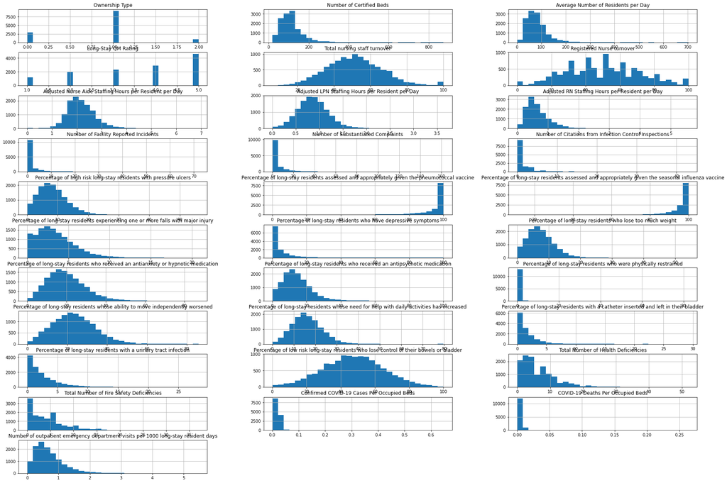

```python
# Visualize distributions
mod_df.hist(bins=30, figsize=(30,25), layout=(13,3));
```

# 5. Assumption Testing - Random Forest Regression with XG Boost

Random forest regression with XG Boost has no assumptions for testing.

# Building the Model

```python
temp_df = mod_df.drop(['Federal Provider Number', 'Provider Name'], axis=1).copy()
temp_df = temp_df.dropna() #Removing NaNs for regression
x = temp_df.drop(['Number of outpatient emergency department visits per 1000 long-stay resident days'], axis=1)
y = temp_df['Number of outpatient emergency department visits per 1000 long-stay resident days']
X = sm.add_constant(x)
```

```python
#80-20 test/train split
from sklearn.model_selection import train_test_split
X_train, X_test, y_train, y_test = train_test_split(X, y, random_state=0, test_size=0.2)
```

```python
#Set basic hyperparameters
from xgboost import XGBRFRegressor
model = XGBRFRegressor(n_estimators=100, subsample=0.9, colsample_bynode=0.2)
```

```python
from sklearn.model_selection import RepeatedKFold
from sklearn.model_selection import cross_validate
cv = RepeatedKFold(n_splits=10, n_repeats=3, random_state=1)
```

# Model Testing

## Evaluating the train model

```python
#Determine initial MAE, RMSE, R^2
score = cross_validate(model, X_train, y_train, scoring=(['neg_mean_absolute_error', 'neg_root_mean_squared_error', 'r2']), cv=cv, n_jobs=-1)
```

```python
from statistics import mean
from statistics import stdev
for scores,val in score.items():
    print(scores, mean(val),',',stdev(val))
```

```
fit_time 1.5069206396738688 , 0.2773521639545116
score_time 0.010210490226745606 , 0.006703930024165353
test_neg_mean_absolute_error -0.2966075961418151 , 0.0065572433453848075
test_neg_root_mean_squared_error -0.4044414226093398 , 0.015826082255341115
test_r2 0.2232523550975405 , 0.01646724181766527
```

The MAE with default hyperparameters is -0.2966 (0.0065) (A larger MAE is better and a perfect model has a MAE of 0)  
The RMSE with default hyperparameters is -0.4044 (0.015)  
The R^2 with default hyperparamaters is 0.22 (0.016)

## Hyperparamater Tuning

### Modifying number of trees (250, 500, 750, 1000)

```python
#IncreaseTrees to 250
tree_model = XGBRFRegressor(n_estimators=250, subsample=0.9, colsample_bynode=0.2)
score = cross_validate(tree_model, X_train, y_train, scoring=(['neg_mean_absolute_error', 'neg_root_mean_squared_error', 'r2']), cv=cv, n_jobs=-1)
for scores,val in score.items():
    print(scores, mean(val), ',', stdev(val))
```

```
fit_time 3.369528651237488 , 0.5715286415681479
score_time 0.01350390116373698 , 0.007877065057835838
test_neg_mean_absolute_error -0.2969530731006803 , 0.006671818955812831
test_neg_root_mean_squared_error -0.40480126119174314 , 0.01594525343976888
test_r2 0.22189427608745071 , 0.016074386905472512
```

```python
#IncreaseTrees to 500
tree_model = XGBRFRegressor(n_estimators=500, subsample=0.9, colsample_bynode=0.2)
score = cross_validate(tree_model, X_train, y_train, scoring=(['neg_mean_absolute_error', 'neg_root_mean_squared_error', 'r2']), cv=cv, n_jobs=-1)
for scores,val in score.items():
    print(scores, mean(val), ',', stdev(val))
```

```
fit_time 6.853989028930664 , 1.1546803777305592
score_time 0.011919903755187988 , 0.0071349916150257355
test_neg_mean_absolute_error -0.2970520651219047 , 0.00665686832215108
test_neg_root_mean_squared_error -0.40491825023595057 , 0.01600174695830033
test_r2 0.22145577938390515 , 0.01592716305764721
```

```python
#IncreaseTrees to 750
tree_model = XGBRFRegressor(n_estimators=750, subsample=0.9, colsample_bynode=0.2)
score = cross_validate(tree_model, X_train, y_train, scoring=(['neg_mean_absolute_error', 'neg_root_mean_squared_error', 'r2']), cv=cv, n_jobs=-1)
for scores,val in score.items():
    print(scores, mean(val), ',', stdev(val))
```

```
fit_time 11.10124781926473 , 1.872167052993025
score_time 0.01916970411936442 , 0.014683190468773512
test_neg_mean_absolute_error -0.297159294033917 , 0.006682114177022371
test_neg_root_mean_squared_error -0.4050694337602153 , 0.016033428217145557
test_r2 0.22087993157844038 , 0.015870063612857255
```

```python
#IncreaseTrees to 1000
tree_model = XGBRFRegressor(n_estimators=1000, subsample=0.9, colsample_bynode=0.2)
score = cross_validate(tree_model, X_train, y_train, scoring=(['neg_mean_absolute_error', 'neg_root_mean_squared_error', 'r2']), cv=cv, n_jobs=-1)
for scores,val in score.items():
    print(scores, mean(val), ',', stdev(val))
```

```
fit_time 13.824930866559347 , 2.161970050340501
score_time 0.016809566815694173 , 0.008952345655591049
test_neg_mean_absolute_error -0.2969028305054752 , 0.00667844416210346
test_neg_root_mean_squared_error -0.40475540373413543 , 0.016037490236190666
test_r2 0.2220892756221308 , 0.015874550790229144
```

Trees = 100:  
MAE = -0.2966 (0.0065), RMSE = -0.4044 (0.015), R^2 = 0.22 (0.016)

Trees = 250:  
MAE = -0.2969 (0.0067), RMSE = -0.405 (0.016), R^2 = 0.22 (0.016)

Trees = 500:  
MAE = -0.29705 (0.0067), RMSE = -0.405 (0.016), R^2 = 0.22 (0.016)

Trees = 750:  
MAE = -0.2971 (0.0067), RMSE = -0.405 (0.016), R^2 = 0.22 (0.016)

### Modify number of features

```python
#Increase features to 0.4
tree_model = XGBRFRegressor(n_estimators=750, subsample=0.9, colsample_bynode=0.4)
score = cross_validate(tree_model, X_train, y_train, scoring=(['neg_mean_absolute_error', 'neg_root_mean_squared_error', 'r2']), cv=cv, n_jobs=-1)
for scores,val in score.items():
    print(scores, mean(val), ',', stdev(val))
```

```
fit_time 16.441640218098957 , 3.178806489800374
score_time 0.013590709368387858 , 0.005310349260570838
test_neg_mean_absolute_error -0.28860247257866595 , 0.006477206943834958
test_neg_root_mean_squared_error -0.3943900950762257 , 0.01599204137025876
test_r2 0.26134144707617785 , 0.020551304333985113
```

```python
#Decrease features to 0.1
tree_model = XGBRFRegressor(n_estimators=750, subsample=0.9, colsample_bynode=0.1)
score = cross_validate(tree_model, X_train, y_train, scoring=(['neg_mean_absolute_error', 'neg_root_mean_squared_error', 'r2']), cv=cv, n_jobs=-1)
for scores,val in score.items():
    print(scores, mean(val), ',', stdev(val))
```

```
fit_time 8.62301425933838 , 1.4969786613858675
score_time 0.019014946619669595 , 0.01550398341394227
test_neg_mean_absolute_error -0.30696239300818506 , 0.007323646144693468
test_neg_root_mean_squared_error -0.4173499346906456 , 0.016167679255095473
test_r2 0.17295347768702332 , 0.012138368985627096
```

Features = 0.1:  
MAE = -0.3069 (0.0073), RMSE = -0.4173 (0.016), R^2 = 0.173 (0.012)

Features = 0.2:  
MAE = -0.2971 (0.0067), RMSE = -0.405 (0.016), R^2 = 0.22 (0.016)

Features = 0.4:  
MAE = -0.2886 (0.0064), RMSE = -0.394 (0.01599), R^2 = 0.2613 (0.02055)

```python
final_model = XGBRFRegressor(n_estimators=750, subsample=0.9, colsample_bynode=0.1)
final_model.fit(X_train, y_train)
```

```
XGBRFRegressor(base_score=0.5, booster='gbtree', colsample_bylevel=1,
               colsample_bynode=0.1, colsample_bytree=1,
               enable_categorical=False, gamma=0, gpu_id=-1,
               importance_type=None, interaction_constraints='',
               max_delta_step=0, max_depth=6, min_child_weight=1, missing=nan,
               monotone_constraints='()', n_estimators=750, n_jobs=12,
               num_parallel_tree=750, objective='reg:squarederror',
               predictor='auto', random_state=0, reg_alpha=0,
               scale_pos_weight=1, subsample=0.9, tree_method='exact',
               validate_parameters=1, verbosity=None)
```

```python
y_pred = final_model.predict(X_test)
y_pred
```

```
array([0.63842845, 0.83766073, 0.96483827, ..., 0.59440964, 0.58628273,
       0.5319548 ], dtype=float32)
```

```python
y_test = y_test.squeeze()
y_test
```

```
3400     0.563651
12517    1.737818
3514     2.018809
2825     0.195712
12812    0.440138
           ...
677      0.217086
182      0.791695
2309     0.078246
8697     0.281475
3086     0.128357
Name: Number of outpatient emergency department visits per 1000 long-stay resident days, Length: 1984, dtype: float64
```

```python
pred_df = pd.DataFrame({'Actual': y_test, 'Predicted': y_pred})
pred_df
```

|  | Actual | Predicted |
| --- | --- | --- |
| 3400 | 0.563651 | 0.638428 |
| 12517 | 1.737818 | 0.837661 |
| 3514 | 2.018809 | 0.964838 |
| 2825 | 0.195712 | 0.466432 |
| 12812 | 0.440138 | 0.502597 |
| ... | ... | ... |
| 677 | 0.217086 | 0.666120 |
| 182 | 0.791695 | 0.832545 |
| 2309 | 0.078246 | 0.594410 |
| 8697 | 0.281475 | 0.586283 |
| 3086 | 0.128357 | 0.531955 |

1984 rows × 2 columns

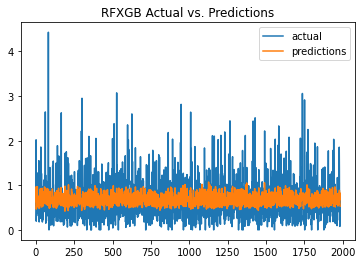

```python
#Visualizing the actual versus predicted values
xax = range(len(y_test))
plt.plot(xax, y_test, label='actual')
plt.plot(xax, y_pred, label='predictions')
plt.title("RFXGB Actual vs. Predictions")
plt.legend()
plt.show()
```

# Model Evaluation

```python
# Evaluating the random forest regression with XG Boost model
from sklearn import metrics
print('MAE', metrics.mean_absolute_error(y_test, y_pred))
print('R^2', metrics.r2_score(y_test, y_pred))
print('RMSE', metrics.mean_squared_error(y_test, y_pred))
```

```
MAE 0.2996527688997647
R^2 0.20373157176230627
RMSE 0.16406031743342978
```

```python
print("Default Number of Estimators:", final_model.n_estimators)
print("Default Max Depth of Trees:", final_model.max_depth)
pd.DataFrame([final_model.feature_importances_], columns=temp_df.columns)
```

```
Default Number of Estimators: 750
Default Max Depth of Trees: None
```

|  | Ownership Type | Number of Certified Beds | Average Number of Residents per Day | Long-Stay QM Rating | Total nursing staff turnover | Registered Nurse turnover | Adjusted Nurse Aide Staffing Hours per Resident per Day | Adjusted LPN Staffing Hours per Resident per Day | Adjusted RN Staffing Hours per Resident per Day | Number of Facility Reported Incidents | ... | Percentage of long-stay residents whose ability to move independently worsened | Percentage of long-stay residents whose need for help with daily activities has increased | Percentage of long-stay residents with a catheter inserted and left in their bladder | Percentage of long-stay residents with a urinary tract infection | Percentage of low risk long-stay residents who lose control of their bowels or bladder | Total Number of Health Deficiencies | Total Number of Fire Safety Deficiencies | Confirmed COVID-19 Cases Per Occupied Beds | COVID-19 Deaths Per Occupied Beds | Number of outpatient emergency department visits per 1000 long-stay resident days |
| --- | --- | --- | --- | --- | --- | --- | --- | --- | --- | --- | --- | --- | --- | --- | --- | --- | --- | --- | --- | --- | --- |
| 0 | 0.0 | 0.033685 | 0.043849 | 0.066709 | 0.200592 | 0.057483 | 0.038026 | 0.016486 | 0.017246 | 0.038874 | ... | 0.011695 | 0.0277 | 0.028114 | 0.02315 | 0.028232 | 0.045762 | 0.013775 | 0.013861 | 0.020968 | 0.021792 |

1 rows × 31 columns

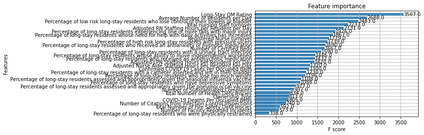

```python
from xgboost import plot_importance
plot_importance(final_model, height=0.8)
pyplot.show()
```

The feature importance score indicates how valuable each feature was in constructing the boosted decision tree in the final model. As can be seen above, the following attributes are the most useful:

- Long-Stay QM Rating
- Average Number of Residents Per Day
- Percentage of low risk long-stay residents who lose control of their bowels or bladder
- Total nursing staff turnover
- Adjusted RN Staffing Hours per Resident per Day